# Project: Investigate a No_show_appointment_Dataset

### Elaborated in a bar plot

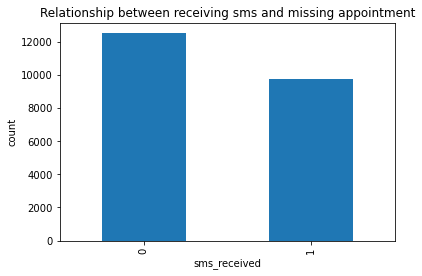

```python
df_no['sms_received'].value_counts().plot(kind = 'bar')
plt.title('Relationship between receiving sms and missing appointment')
plt.xlabel('sms_received')
plt.ylabel('count');
```

From the two bar plots, that the use of sms as as reminder of appointments is not so effective as a greater number of patients that show up for appointments did not receive text message.lets buttress on this by checking the proportion of patients that recieve sms met thier appointment and those that recieved but did not meet.

```python
#count of patients that did not receive sms but met their appointment
count_sms_received_yes_0 = df_yes.query('sms_received == 0').count()['sms_received']
count_sms_received_yes_0
```

```
62510
```

```python
#count of patients that received sms and met their appointment
count_sms_received_yes_1 = df_yes.query('sms_received == 1').count()['sms_received']
count_sms_received_yes_1
```

```
25698
```

```python
#total number of patients that met their appointments
total_sms_received_yes = df_yes['sms_received'].count()
total_sms_received_yes
```

```
88208
```

```python
#proportion of patients did not recieve sms and those that recieved sms in the total number of patients that met their appointment
proportion_yes_0 = proportion(count_sms_received_yes_0, total_sms_received_yes)
proportion_yes_1 = proportion(count_sms_received_yes_1, total_sms_received_yes)
proportion_yes_0, proportion_yes_1
```

```
(0.7086658806457464, 0.2913341193542536)
```

```python
#counting the number of patients that did not receive sms and missed their appointment
count_sms_received_no_0 = df_no.query('sms_received == 0').count()['sms_received']
count_sms_received_no_0
```

```
12535
```

```python
#counting the number of patients that received sms but missed appointment
count_sms_received_no_1 = df_no.query('sms_received == 1').count()['sms_received']
count_sms_received_no_1
```

```
9784
```

```python
#the total number of patients that missed thier appointment
total_sms_received_no = df_no['sms_received'].count()
total_sms_received_no
```

```
22319
```

```python
#proportion of patients did not recieve sms and those that recieved sms in the total number of patients that missed their appointment
proportion_no_0 = proportion(count_sms_received_no_0, total_sms_received_no)
proportion_no_1 = proportion(count_sms_received_no_1, total_sms_received_no)
proportion_no_0, proportion_no_1
```

```
(0.5616291052466509, 0.43837089475334917)
```

From the proportions of patients that recieve sms and met thier appointment and those that recieved but did not meet, it can not be categorically said that patients that recieve sms meet appointment more or that patients that receive sms meet appointment because of the sms. Further statistical test should be done to arrive at that conclusion.

### Research Question 4- Do patients on scholarship meet appointments more than those that are not?

```python
#checking the unique values in the scholarship column
df.scholarship.unique()
```

```
array([0, 1], dtype=int64)
```

The column contains two unique values, 0 and 1. 0 represents patients that are not enrolled in Brasilian welfare program while 1 represents those that are enrolled in the program.

```python
#showing how the effect of the scholarship on patients meeting their appointments
df.groupby(['scholarship', 'no_show']).count()['sms_received']
```

```
scholarship  no_show
0            No         79925
             Yes        19741
1            No          8283
             Yes         2578
Name: sms_received, dtype: int64
```

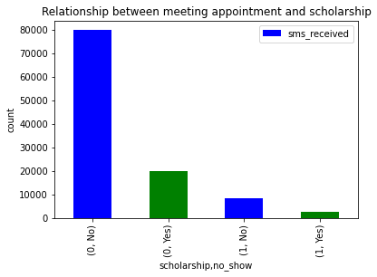

```python
#to show the relationship between appointment and scholarship
Appointments_by_scholarship = df.groupby( ['scholarship', 'no_show']).count()['sms_received']
Appointments_by_scholarship.plot(kind = 'bar', title = 'Relationship between meeting appointment and scholarship', color = ('blue', 'green'))
plt.legend()
plt.xlabel('scholarship,no_show')
plt.ylabel('count');
```

```python
#checking for the proportion of patients in scholarship in the total number of patients that meet that appointments
df_yes.groupby('scholarship').count()['no_show']
```

```
scholarship
0    79925
1     8283
Name: no_show, dtype: int64
```

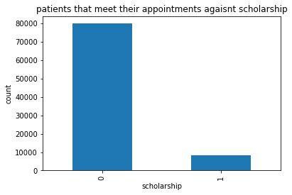

```python
df_yes.groupby('scholarship').count()['no_show'].plot(kind = 'bar', title = 'patients that meet their appointments agaisnt scholarship')
plt.ylabel('count');
```

## Conclusions

> From the analysis, holder patients were found to meet appointments more than younger ones though this difference is not strong and requires further statistical analysis to back it up.

> The gender of the patients has little or no effect on whether the patients meets an appointment or not.

> The effect of sending sms on patients ability to meet appointments can not be ascertain with information on the dataset or descriptive statistics. it can not be categorically said that patients that recieve sms meet appointment more or that patients that receive sms meet appointment because of the sms. Further statistical test should be done to arrive at that conclusion.

> A major limitation of the analysis is the scope of the data. Additional information were needed to answer some questions. Also, the analysis was limited to only descriptive statistics. To make predictions and arrive at some conlcusions, inferential analysis and machine learning has to be employed